# Tugas Besar ADS

Kaleb Filbert Istel

2025-11-21

## Data preprocessing & Cleaning

```r
library(dplyr)
```

```r
library(readr)
library(stringr)
library(ggplot2)

raw_df <- read_csv("D:/Kuliah/Sem 3/Analisis Data Statistika (ADS)/TUBES/ads-dataset.csv", show_col_types = FALSE)

head(raw_df)
```

```
## # A tibble: 6 × 20
##   NIM   `Program Studi :` `IPK Terakhir :` `Jenis Kelamin` `Tinggi Badan :`
##   <chr> <chr>             <chr>            <chr>           <chr>
## 1 01    Sains Data        4. 0             Laki-laki       160
## 2 02    Matematika        3.8              Laki-laki       169
## 3 03    Sains Data        3.4              Perempuan       150
## 4 04    Sains Data        3.86             Laki-laki       170
## 5 05    Sains Data        3.97             Laki-laki       170
## 6 06    Sains Data        3.35             Perempuan       154
## # ℹ 15 more variables: `Berat Badan :` <chr>, `Pendidikan terakhir` <chr>,
## #   `Rata-rata belajar perminggu (dalam jam) :` <chr>,
## #   `Apakah penerima beasiswa :` <chr>,
## #   `Asal Daerah (Kota beserta Provinsi) : \nEx : Padang, Sumatera Barat` <chr>,
## #   `Pekerjaan saat ini (selain kuliah)` <chr>,
## #   `Akses Internet (yang paling sering digunakan)` <chr>,
## #   `Keterlibatan Organisai` <chr>, …
```

```r
#Fungsi pembersih rerata jam belajar/minggu
clean_hours <- function(text){
  text_lower <- tolower(text)
  hours <- as.numeric(str_extract(text_lower, "\\d+"))

  # NA jika gaada jam/angka
  if(is.na(hours)){
    return(NA)
  }

  is_per_day <- str_detect(text_lower, "hari|perhari|per hari|/hari")
  is_per_week <- str_detect(text_lower, "minggu|perminggu|per minggu|/minggu")

  if (is_per_day){
    hours_per_week <- hours * 7 #jadi harian
  } else {
    hours_per_week <- hours
  }

  if(is.na(hours_per_week) || hours_per_week == 0 || hours_per_week>84){
    return(NA)
  }

  return(hours_per_week)
}

text_time<- raw_df$`Rata-rata belajar perminggu (dalam jam) :`

#fungsi pembersih IPK
clean_ipk <- function(x){
  if(is.na(x)) return(NA)

  # Ambil bagian angka
  value <- str_extract(x, "\\d+[\\.,]?\\d*")

  if (is.na(value)) return(NA)

  # Jika bentuknya "3." atau "3," → jadikan "3"
  value <- gsub("[\\.,]$", "", value)

  # Ganti koma ke titik untuk jadi desimal
  value <- gsub(",", ".", value)

  # Konversi ke numeric
  num <- as.numeric(value)

  # Validasi rentang IPK wajar
  if(is.na(num) || num < 0 || num > 4) return(NA)

  return(num)
}


ipkraw <- raw_df$`IPK Terakhir :`


df <- data.frame(
  ipk = sapply(ipkraw, clean_ipk),
  hours_per_week = sapply(text_time, clean_hours)
)

df_clean<- df %>%
  filter(!is.na(hours_per_week))

df_clean <- df_clean %>%
  filter(!is.na(ipk))

head(df_clean)
```

```
##    ipk hours_per_week
## 1 4.00              3
## 2 3.80             48
## 3 3.40             17
## 4 3.86              4
## 5 3.97             30
## 6 3.35              3
```

```r
model <- lm(ipk ~ hours_per_week, data = df_clean)
summary(model)
```

```
##
## Call:
## lm(formula = ipk ~ hours_per_week, data = df_clean)
##
## Residuals:
##     Min      1Q  Median      3Q     Max
## -3.3114 -0.2375  0.0952  0.3886  0.7380
##
## Coefficients:
##                Estimate Std. Error t value Pr(>|t|)
## (Intercept)    3.256552   0.047407  68.693   <2e-16 ***
## hours_per_week 0.002744   0.002264   1.212    0.226
## ---
## Signif. codes:  0 '***' 0.001 '**' 0.01 '*' 0.05 '.' 0.1 ' ' 1
##
## Residual standard error: 0.6487 on 323 degrees of freedom
## Multiple R-squared:  0.004529,   Adjusted R-squared:  0.001447
## F-statistic: 1.469 on 1 and 323 DF,  p-value: 0.2263
```

Koefisien Regresi:

| Komponen | Nilai | Interpretasi |
| --- | --- | --- |
| **Intercept** | **3.256552** | Saat jam belajar = 0, IPK yang diprediksi ≈ **3.26**. |
| **hours_per_week (β1)** | **0.002744** | **Setiap tambahan 1 jam belajar per minggu hanya menaikkan IPK sebesar 0.0027 poin**, dan secara statistik *tidak signifikan*. |
| **p-value (β1)** | **0.226** | Tidak signifikan pada taraf 5% → **jam belajar tidak terbukti memengaruhi IPK secara linear**. |

Goodness of Fit (Kualitas Model)

| Statistik | Nilai | Interpretasi |
| --- | --- | --- |
| **Multiple R-squared** | **0.004529** | Model hanya menjelaskan **0.45%** variasi IPK. |
| **Adjusted R-squared** | **0.001447** | Setelah penyesuaian, kemampuan prediksi model makin kecil. |
| **F-statistic** | **1.469** | Model tidak signifikan. |
| **p-value (model)** | **0.2263** | Secara keseluruhan, model regresi **tidak signifikan**. |

MODEL REGRESI: **IPK = 3.256552 +0.002744 * Jam belajar per minggu**

Karena model regresi sederhana ini hasil dari OLS (Ordinary least square)/ metode Kuadrat terkecil.

Kita sebaiknya mengecek apakah datanya memenuhi semua **asumsi klasik OLS nya.**

Karena jika memenuhi semua asumsi, model regresi ini akan bersifat **BLUE (Best Linear Unbiased Estimator)** model ini dapat digunakan untuk melakukan estimasi dan inferensi statistik secara valid dalam konteks hubungan IPK dan Jam belajar

## Uji korelasi

```r
# Korelasi Pearson
cor_xy <- cor(df_clean$hours_per_week, df_clean$ipk, method = "pearson")
cor_xy
```

```
## [1] 0.06729458
```

## Uji **Asumsi Klasik Regresi (OLS)**

### 1. Uji linearitas

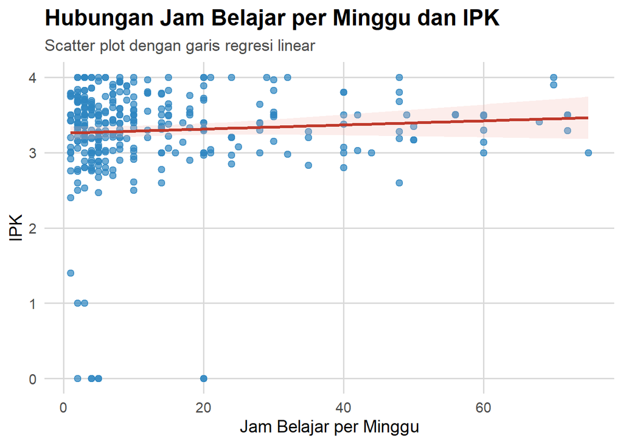

```r
library(ggplot2)

ggplot(df_clean, aes(x = hours_per_week, y = ipk)) +
  geom_point(color = "#2E86C1", size = 2.3, alpha = 0.7) +          # titik data
  geom_smooth(method = "lm", se = TRUE, color = "#C0392B",
              linewidth = 1.2, fill = "#F5B7B1", alpha = 0.25) +    # garis regresi + band CI
  labs(
    title = "Hubungan Jam Belajar per Minggu dan IPK",
    subtitle = "Scatter plot dengan garis regresi linear",
    x = "Jam Belajar per Minggu",
    y = "IPK"
  ) +
  theme_minimal(base_size = 14) +
  theme(
    plot.title = element_text(face = "bold", size = 18),
    plot.subtitle = element_text(size = 13, color = "gray30"),
    panel.grid.minor = element_blank(),
    panel.grid.major = element_line(color = "gray85")
  )
```

### 2. Ekspektasi nilai error = 0

```r
# Residual dari model
res <- resid(model)
#fit model
fit<-fitted(model)

#itung rerata residual
mean_res<-mean(res)
mean_res
```

```
## [1] -9.275516e-18
```

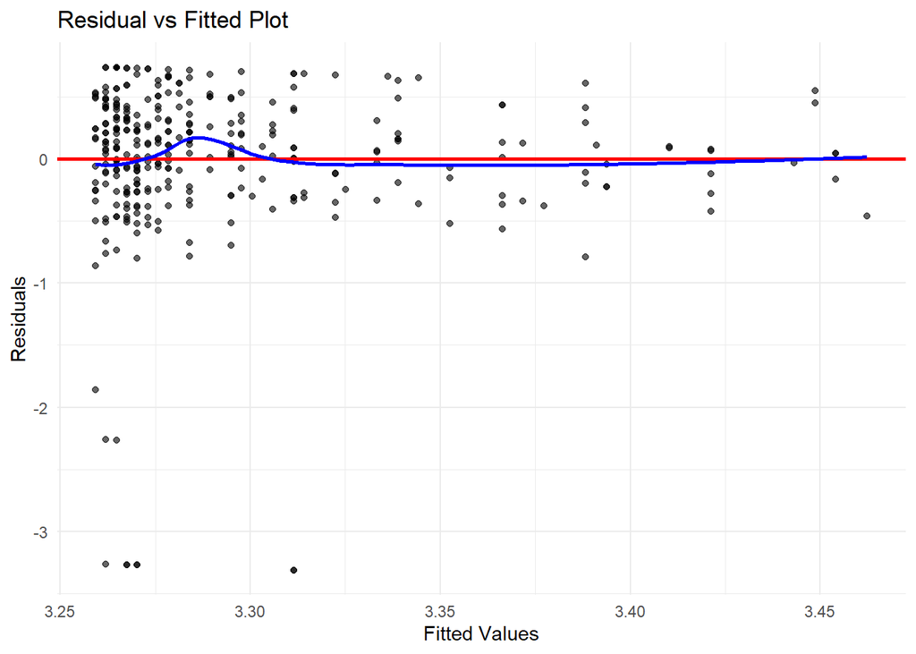

```r
# Membuat plot residual terhadap nilai prediksi
ggplot(data.frame(fitted = fit, residuals = res),
       aes(x = fitted, y = residuals)) +
  geom_point(alpha = 0.6) +
  geom_hline(yintercept = 0, color = "red", linewidth = 1) +
  geom_smooth(method = "loess", se = FALSE, color = "blue") +
  labs(
    title = "Residual vs Fitted Plot",
    x = "Fitted Values",
    y = "Residuals"
  ) +
  theme_minimal()
```

Interpretasi:

1. **Residual mengambang di sekitar 0 → E(ε) = 0 terpenuhi**

Garis merah = garis residual nol.  
Mayoritas titik tersebar di sekitar garis tersebut → *mean residual ≈ 0* ✔

Ini sejalan dengan hasil mean residual = **–9e–18**, yang praktis **nol sempurna** karena OLS.

2. Tidak ada pola melengkung besar → linearitas cukup terpenuhi

   Garis biru (LOESS) sempat naik sedikit, lalu turun, tapi:

   amplitudonya kecil

   tidak membentuk pola bowl atau wave besar

   tidak ada tren sistematis

   Kesimpulan: **tidak ada indikasi kuat pelanggaran linearitas**.
3. **Homoskedastisitas: sebagian besar tampak wajar**

```
Jika titik menyebar acak di sekitar garis 0 dan lebar sebarannya relatif sama, asumsi homoskedastisitas cenderung terpenuhi. tidak terlihat pola “kipas” (fan shape) atau corong (semakin melebar / menyempit), yang beruoa indikasi heteroskedastisitas.
```

4. Ada outlier beberapa titik di bawah -2 dan -3 tapi tidak mengganggu tren

### 3. Homoskedastisitas (Varians Error Konstan)

sudah bisa dilihat visualisasinya di graf garis merah sebelumnya, disini lebih ke uji numerik BP (Breusch-Pagan) nya

(Jika varians error berubah-ubah (heteroskedastisitas), maka estimasi tetap tidak bias tetapi tidak efisien, dan uji statistik seperti uji t menjadi tidak valid.)

Jika homoskedastisitas/varians error konstan, uji t menjadi VALID

```r
library(lmtest)
bptest(model)
```

```
##
##  studentized Breusch-Pagan test
##
## data:  model
## BP = 1.7881, df = 1, p-value = 0.1812
```

Hipotesis tes homoskedastisitas:

H0 = homoskedastisitas/ tidak ada bukti heteroskedastisitas

H1 = terbukti hetero

p-value (**0.1812**) > 0.05 → gagal tolak H0 -> tidak ada bukti heteroskedastisitas -> asumsi homoskedaskitas terpenuhi.

### 4. Uji error terdistribusi normal?/ normalitas residual

```r
# Uji Shapiro-Wilk
shapiro.test(res)
```

```
##
##  Shapiro-Wilk normality test
##
## data:  res
## W = 0.71376, p-value < 2.2e-16
```

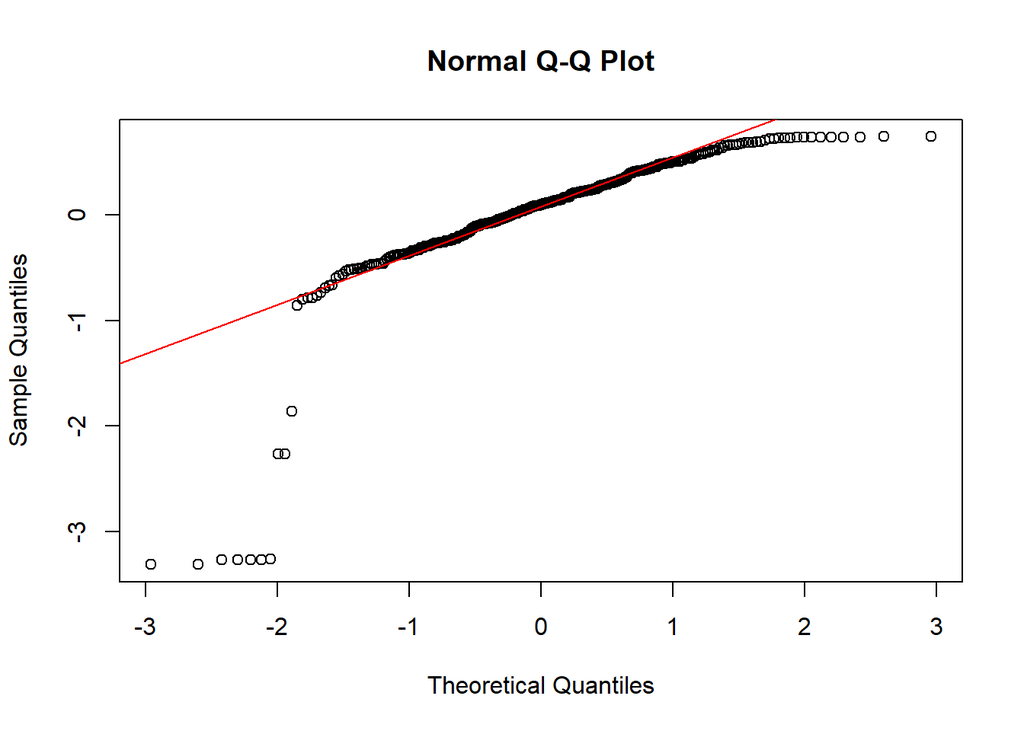

```r
# Q-Q plot
qqnorm(res)
qqline(res, col = "red")
```

**Interpretasi**

Uji Shapiro–Wilk memiliki hipotesis:

**H0:** residual berdistribusi normal

**H1:** residual *tidak* berdistribusi normal

Karena:

**p-value < 0.05,** bahkan **sangat kecil (< 2.2e−16)**

➡️ **Tolak H0**  
➡️ **Residual tidak berdistribusi normal**

Ini menunjukkan bahwa asumsi **normalitas error** pada regresi linear tidak terpenuhi secara statistik.

Namun walaupun tidak terpenuhi asumsi ini, karena data besar (n>300):

Regresi OLS *tetap konsisten*

Uji t dan uji F *tetap robust*

Pelanggaran normalitas sering terjadi dan *tidak fatal*

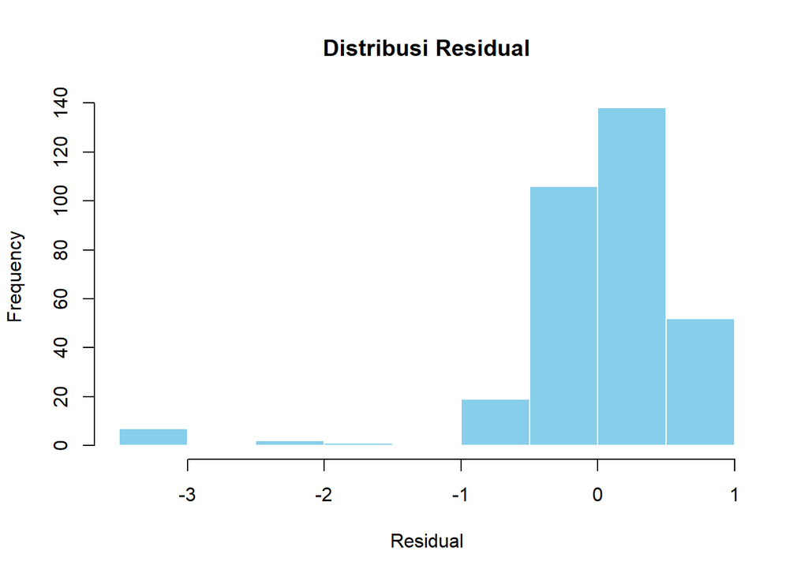

```r
# Histogram residual
hist(res,
main = "Distribusi Residual",
xlab = "Residual",
col = "skyblue",
border = "white",
breaks = 10)
```

Interpretasi:

1. Histogram sangatlah skewed, left skewed
2. terdapat lonceng, tapi ada ekor” kecil selain itu

   DATA TIDAK berdistribusi NORMAL